# Assignment 4. Spatial Data

Introduction to Data Science

10/01/2020

## A map of German counties

1. Download spatial data on German administrative units from http://sg.geodatenzentrum.de/web_download/vg/vg1000-ew_3112/utm32s/shape/vg1000-ew_3112.utm32s.shape.ebenen.zip. Use R functions to (a) execute the download and (b) unzip the file.

```r
download.file(url="http://sg.geodatenzentrum.de/web_download/vg/vg1000-ew_3112/utm32s/shape/vg1000-ew_3112.utm32s.shape.ebenen.zip", destfile= "data.zip", method="libcurl")
unzip("data.zip")
```

2. Import the county shapefile (VG1000_KRS.shp) into R.

```r
list.files()
```

```
[1] "assignment-04.html"                 "assignment-04.Rmd"
[3] "data"                               "data.zip"
[5] "data1"                              "data3.ebenen"
[7] "dataset.zip"                        "vg1000-ew_3112.utm32s.shape.ebenen"
```

```r
county <- st_read("vg1000-ew_3112.utm32s.shape.ebenen/vg1000-ew_ebenen/VG1000_KRS.shp")
```

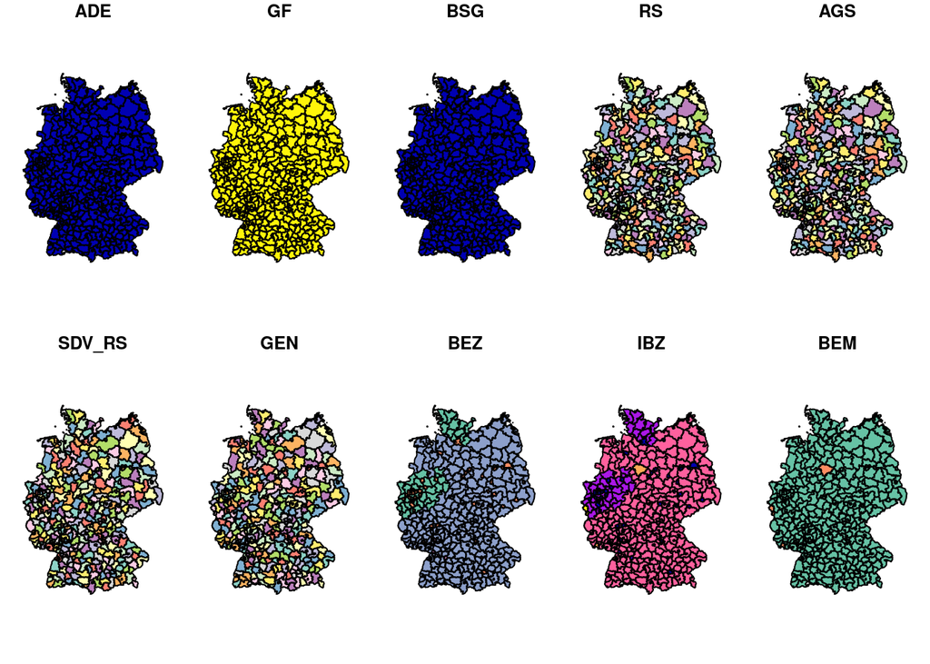

```r
plot(county)
```

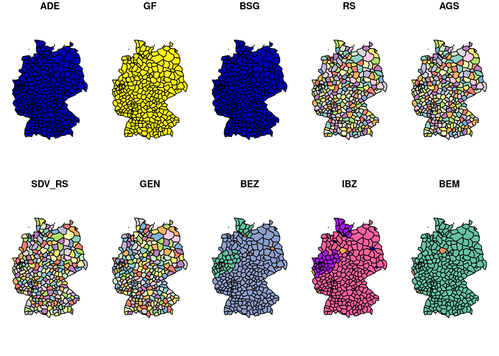

```r
county_low <- ms_simplify(county, keep = 0.001)
plot(county_low)
```

## Data on anti-refugee violence in Germany

1. Get the arvig package from https://github.com/davben/arvig.

```r
library(arvig)
data("arvig")
```

2. Filter out events that belong into the “other” category or are associated with more than one category. Furthermore, restrict the data to events that took place between 2014 and 2015.

```r
library(dplyr)
new_arvig <- arvig %>%
filter(date >= ("2014-01-01") & date <= ("2015-12-31"), !grepl("[\\&]|other",category_en))
```

3. Provide a frequency table (or appropriate plot) of the total number of events (a) by category and (b) by state.

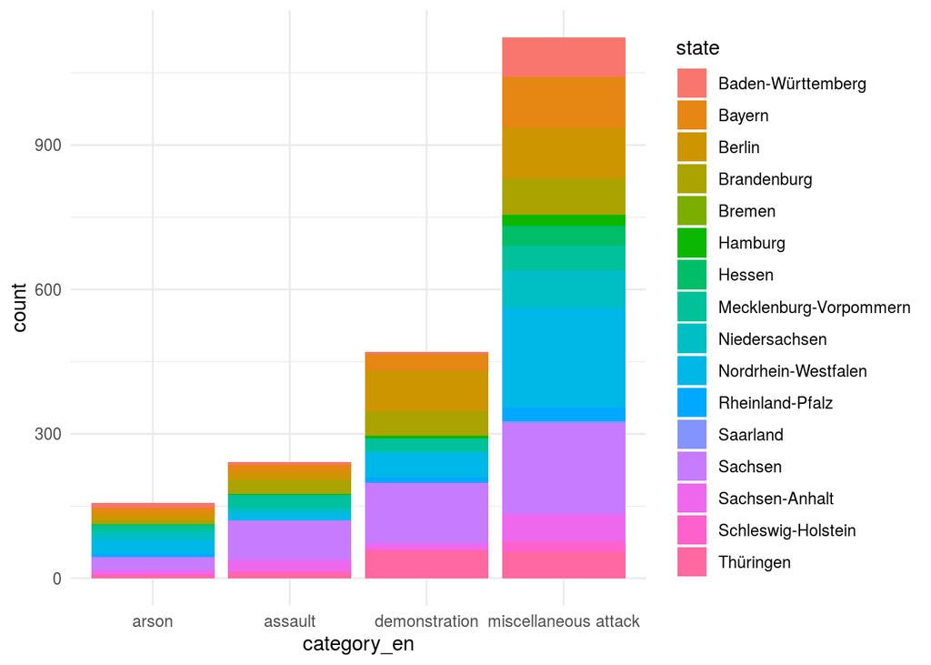

```r
new_arvig %>% ggplot(aes(category_en, stat = "count",
              fill = state)) + theme_minimal() +
              geom_bar()
```

```r
table(new_arvig$state, new_arvig$category_en)
```

```
                         arson assault demonstration miscellaneous attack
  Baden-Württemberg         10       5             4                   83
  Bayern                    12      15            34                  105
  Berlin                    13      17            86                  106
  Brandenburg                7      28            50                   75
  Bremen                     2       0             0                    0
  Hamburg                    0       2             5                   23
  Hessen                     3       2             0                   41
  Mecklenburg-Vorpommern    13      26            28                   51
  Niedersachsen             15      10             2                   77
  Nordrhein-Westfalen       30      15            51                  208
  Rheinland-Pfalz            7       1            11                   29
  Saarland                   1       1             1                    4
  Sachsen                   26      81           125                  189
  Sachsen-Anhalt             8      24            13                   57
  Schleswig-Holstein         3       3             2                   22
  Thüringen                  6      11            58                   54
```

3. Turn the arvig dataset into an sf object using the st_as_sf function and the string “+proj=longlat +ellps=GRS80 +datum=WGS84 +no_defs” to define the CRS.

```r
arvig_sf <- st_as_sf(new_arvig, coords =
              c("longitude", "latitude"),
              crs = "+proj=longlat +ellps=GRS80 +datum=WGS84 +no_defs", agr = "constant")
arvig_sf <- st_transform(arvig_sf, 26978)
```

5. Plot the count map and add the events as dots (colored by type). You might have to transform the CRS of the events data to make it compatible with the county spatial data.

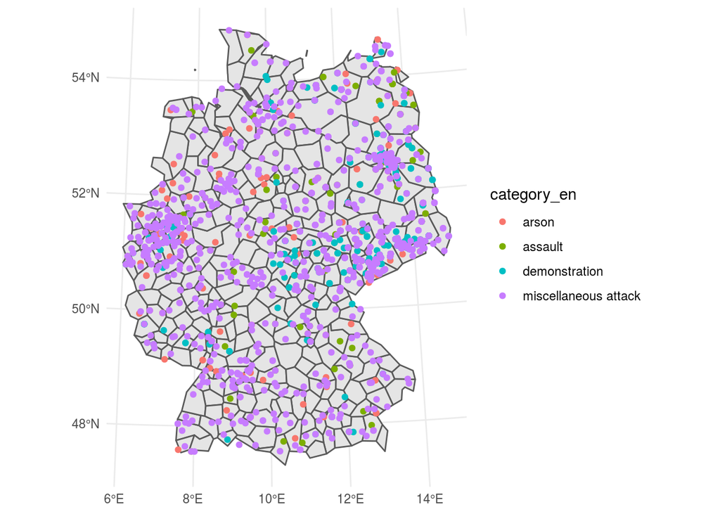

```r
ggplot(county_low)  + geom_sf() +
      theme_minimal() + geom_sf(data =arvig_sf,
      mapping = aes(col = category_en))
```

```r
arvig_sf <- st_transform(arvig_sf, 26978)
county_low <- st_transform(county_low, 26978)
join <- st_intersection(x = county_low, y = arvig_sf)
# Generate the count variable by county
# Normalize it by population
# Sort by count variable

join <- as.data.frame(join)
final <- join %>% group_by(GEN, EWZ) %>%
                  tally() %>%
                  mutate(stats = n/EWZ*100,000) %>%
                  arrange(desc(stats))

final[1:10,]
```

```
# A tibble: 10 x 5
# Groups:   GEN [10]
   GEN                                 EWZ     n    stats   `0`
   <chr>                             <int> <int>    <dbl> <dbl>
 1 Pinneberg                             0     1 Inf          0
 2 Sächsische Schweiz-Osterzgebirge 245418    78   0.0318     0
 3 Greiz                             99275    20   0.0201     0
 4 Erzgebirgskreis                  340373    60   0.0176     0
 5 Saalekreis                       185494    31   0.0167     0
 6 Leipzig                          258008    42   0.0163     0
 7 Frankfurt (Oder)                  58237     9   0.0155     0
 8 Börde                            172619    26   0.0151     0
 9 Barnim                           180864    27   0.0149     0
10 Dresden                          551072    79   0.0143     0
```

```r
rm(joint2)
```